# Simulation

Julian Frattini

2026-02-22

This notebook contains the simulation of a type II formalization of the requirements engineering (RE) phase from an information-based perspective. The simulation is based on cumulative distribution-functions of the beta-distribution, which is defined by two parameters.

## Case

The illustrated case focuses on one information storage (a developer) requiring information. In the example, the developer has two options:

1. Formal path: Customer $\rightarrow$ Requirements Engineer $\rightarrow$ Requirements Specification $\rightarrow$ Developer
2. Informal path: Customer $\rightarrow$ Developer

According to the information-based perspective, the developer would chose the path of least resistance. In this case, resistance is operationalized via *effectiveness*, i.e., the developer gravitates towards the path that provides the most information.

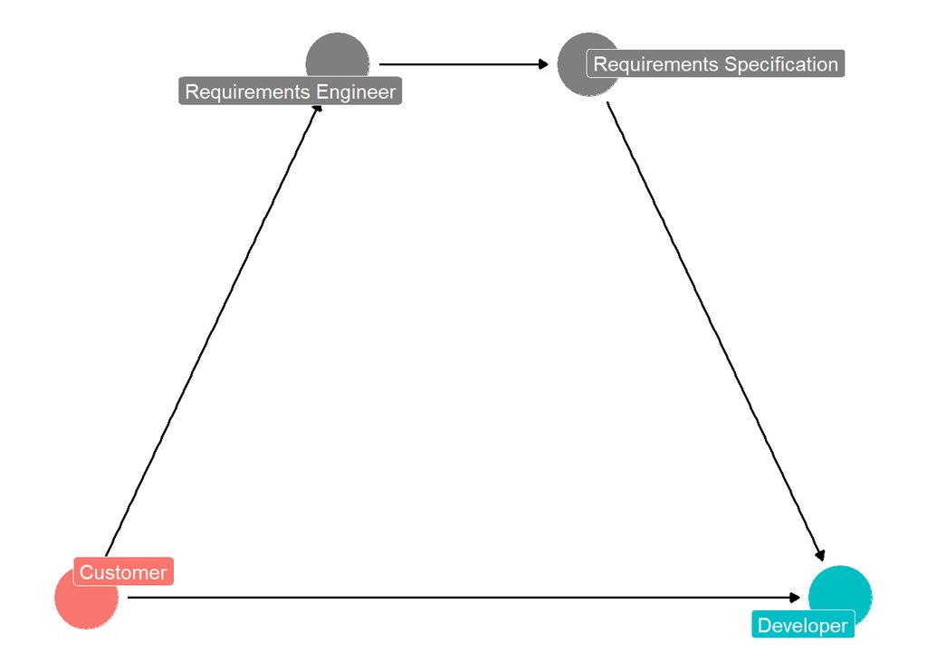

```r
dag <- dagify(
  reng ~ customer,
  srs ~ reng,
  dev ~ srs + customer,

  exposure = "customer", outcome = "dev",
  labels = c(customer = "Customer", reng = "Requirements Engineer",
             srs = "Requirements Specification", dev = "Developer"),

  coords = list(
    x = c(customer = 0, reng = 1, srs = 2, dev = 3),
    y = c(customer = 0, reng = 1, srs = 1, dev = 0)
  )
)

# visualize the DAG
ggdag_status(dag, use_labels = "label", text = FALSE) +
  guides(fill = "none", color = "none") +
  theme_dag()
```

## Formalism

Each transfer of information $x \rightarrow y$ is defined by a transfer function:

$$f(i: \text{information}, c:
\text{complexity}, s: \text{skill}, t: \text{time}, t_{max}:
\text{time}) \rightarrow i: \text{information}$$

1. **Input information** $i \in [0; 1]$, the information provided by the sender
2. **Task complexity** $c \in \mathbb{R}^+$, the baseline challenge of the performed activity
3. **Stakeholder skill** $s \in \mathbb{R}^+$, the ability of the stakeholder performing the activity
4. **Time spent** $t \in [0; t_{max}]$, the amount of resources (here measured in hours) invested into the activity
5. **Maximum time** $t_{max} \in \mathbb{R}^+$, the amount of resources (here measured in hours) the activity would require to output 100% information.

```r
f <- function(i, c, s, t, tmax) {
  return(cdf.beta(alpha = c, beta = s, x = t, range = tmax)*i)
}
```

The function $f(i, c, s, t, t_{max})$ is then realized as the cumulative distribution function of a beta-distribution:

$$f(i, c, s, t) = \text{CDF}_\beta \left(
\alpha = c, \beta = s, x = \frac{t}{t_{max}} \right) * i$$

This way, higher values of complexity $c$ will make transferring more difficult, but higher values of skill $s$ make it easier. The more time $t$ spent on the activity, the more information will be transferred. Finally, the input information $i$ defines the upper bound of information to transfer. The following figure illustrates the relation between the variables.

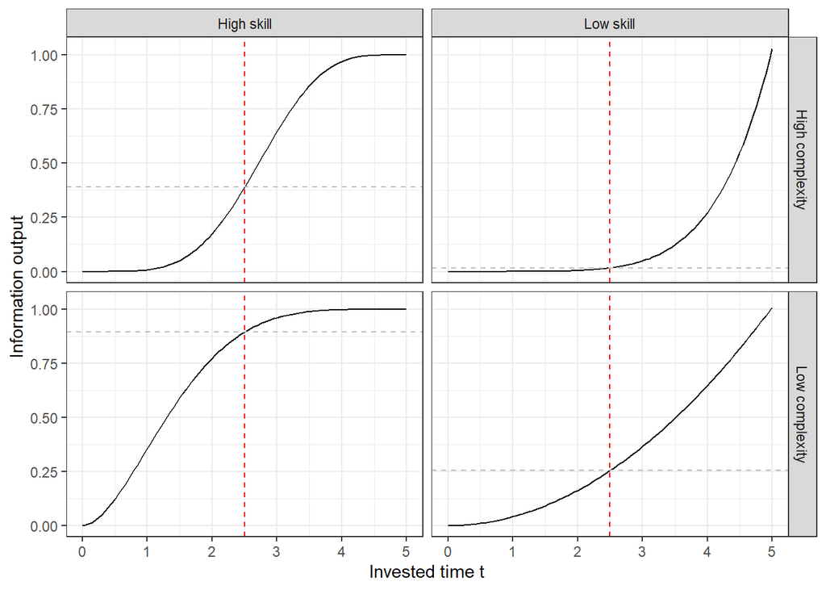

```r
t <- 2.5
tmax <- 5

d <- expand.grid(
  x = seq(from = 0, to = 5, length.out = granularity),
  complexity = c(2, 6),
  skill = c(1, 5)
) %>%
  rowwise() %>%
  mutate(i = cdf.beta(alpha = complexity, beta = skill, x = x, range = tmax))

d.hline <- expand.grid(
  complexity = c(2, 6),
  skill = c(1, 5)
) %>%
  rowwise() %>%
  mutate(hline = cdf.beta(alpha = complexity, beta = skill, x = t, range = tmax)) %>%
  mutate(
    complexity = ifelse(complexity == 2, "Low complexity", "High complexity"),
    skill = ifelse(skill == 1, "Low skill", "High skill")
  )

d %>%
  mutate(
    complexity = ifelse(complexity == 2, "Low complexity", "High complexity"),
    skill = ifelse(skill == 1, "Low skill", "High skill")
  ) %>%
  ggplot(aes(x = x, y = i)) +
    geom_line() +
    facet_grid(rows = vars(complexity), cols = vars(skill)) +
    labs(x = "Invested time t", y = "Information output") +
    geom_vline(xintercept = t, color = "red", linetype = "dashed") +
    geom_hline(data = d.hline, aes(yintercept = hline), color = "grey", linetype = "dashed") +
    theme_bw()
```

```r
ggsave("../figures/results/sim-function.pdf", device = "pdf", unit = "cm", width = 11, height = 7)
```

## Simulation

Now we can simulate the case above in two scenarios: waterfall and agile. The main difference is that in the waterfall scenario, the complexity of the *direct communication* (customer $\rightarrow$ developer) is much higher than in the agile scenario.

```r
# configuration
info.customer <- 0.8
# elicitation activity (customer -> req engineer)
c.elicitation <- 6
s.elicitation <- 5
t.elicitation <- 6
tmax.elicitation <- 8
# specification activity (req engineer -> specification)
c.specification <- 4
s.specification <- 7
t.specification <- 3
tmax.specification <- 6
# reading activity (specification -> developer)
c.reading <- 2
s.reading <- 4
t.reading <- 2
tmax.reading <- 3
# direct communication activity (customer -> developer)
c.direct <- 12
s.direct <- 3
t.direct <- 6
tmax.direct <- 8

# simulation
info.elicitation <- f(i = info.customer, c = c.elicitation, s = s.elicitation,
                       t = t.elicitation, tmax = tmax.elicitation)
info.specification <- f(i = info.elicitation, c = c.specification, s = s.specification,
                         t = t.specification, tmax = tmax.specification)
info.reading <- f(i = info.specification, c = c.reading, s = s.reading,
                   t = t.reading, tmax = tmax.reading)
info.communicating <- f(i = info.customer, c = c.direct, s = s.direct,
                         t = t.direct, tmax = tmax.direct)
print(paste0("Information flow via the traditional path: elicitation (", info.elicitation,
             "), specifiation (", info.specification, "), reading (", info.reading, ")"))
```

```
## [1] "Information flow via the traditional path: elicitation (0.742097725991017), specifiation (0.620576369956203), reading (0.594865104058081)"
```

```r
print(paste0("Information flow via the agile path: directly communicating (", info.communicating, ")"))
```

```
## [1] "Information flow via the agile path: directly communicating (0.236560434816309)"
```

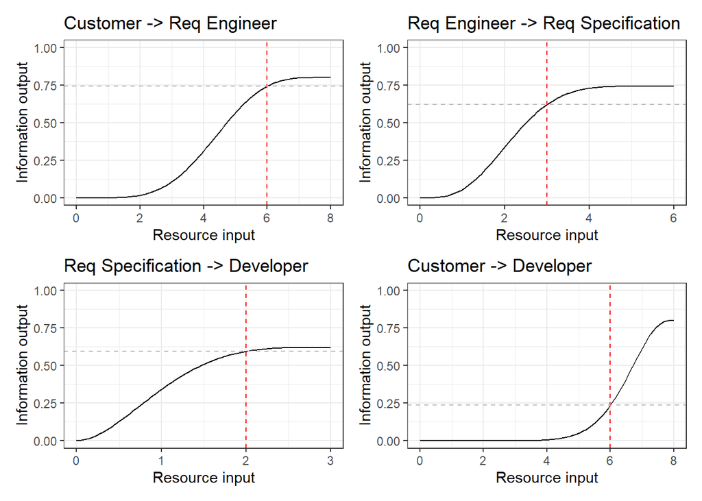

```r
# visualization
plt.customer2reng <- plot.cdf(cdf.beta(alpha = c.elicitation, beta = s.elicitation) * info.customer,
                              range = tmax.elicitation) +
  geom_vline(xintercept = t.elicitation, color = "red", linetype = "dashed") +
  geom_hline(yintercept = info.elicitation, color = "grey", linetype = "dashed") +
  ggtitle("Customer -> Req Engineer")
plt.reng2srs <- plot.cdf(cdf.beta(alpha = c.specification, beta = s.specification) * info.elicitation,
                         range = tmax.specification) +
  geom_vline(xintercept = t.specification, color = "red", linetype = "dashed") +
  geom_hline(yintercept = info.specification, color = "grey", linetype = "dashed") +
  ggtitle("Req Engineer -> Req Specification")
plt.srs2dev <- plot.cdf(cdf.beta(alpha = c.reading, beta = s.reading) * info.specification,
                        range = tmax.reading) +
  geom_vline(xintercept = t.reading, color = "red", linetype = "dashed") +
  geom_hline(yintercept = info.reading, color = "grey", linetype = "dashed") +
  ggtitle("Req Specification -> Developer")

plt.customer2dev <- plot.cdf(cdf.beta(alpha = c.direct, beta = s.direct) * info.customer,
                             range = tmax.direct) +
  geom_vline(xintercept = t.direct, color = "red", linetype = "dashed") +
  geom_hline(yintercept = info.communicating, color = "grey", linetype = "dashed") +
  ggtitle("Customer -> Developer")

(plt.customer2reng | plt.reng2srs) / (plt.srs2dev | plt.customer2dev)
```

Now, when just reducing the complexity of the *directly communicating* transfer from `c=12` to `c=5`, the resulting information flow will be entirely different.

```r
# configuration
info.customer <- 0.8
# elicitation activity (customer -> req engineer)
c.elicitation <- 6
s.elicitation <- 5
t.elicitation <- 6
tmax.elicitation <- 8
# specification activity (req engineer -> specification)
c.specification <- 4
s.specification <- 7
t.specification <- 3
tmax.specification <- 6
# reading activity (specification -> developer)
c.reading <- 2
s.reading <- 4
t.reading <- 2
tmax.reading <- 3
# direct communication activity (customer -> developer)
c.direct <- 5
s.direct <- 3
t.direct <- 6
tmax.direct <- 8

# simulation
info.elicitation <- f(i = info.customer, c = c.elicitation, s = s.elicitation,
                       t = t.elicitation, tmax = tmax.elicitation)
info.specification <- f(i = info.elicitation, c = c.specification, s = s.specification,
                         t = t.specification, tmax = tmax.specification)
info.reading <- f(i = info.specification, c = c.reading, s = s.reading,
                   t = t.reading, tmax = tmax.reading)

info.communicating <- f(i = info.customer, c = c.direct, s = s.direct,
                         t = t.direct, tmax = tmax.direct)
print(paste0("Information flow via the traditional path: elicitation (", info.elicitation,
             "), specifiation (", info.specification, "), reading (", info.reading, ")"))
```

```
## [1] "Information flow via the traditional path: elicitation (0.742097725991017), specifiation (0.620576369956203), reading (0.594865104058081)"
```

```r
print(paste0("Information flow via the agile path: directly communicating (", info.communicating, ")"))
```

```
## [1] "Information flow via the agile path: directly communicating (0.613395701814)"
```

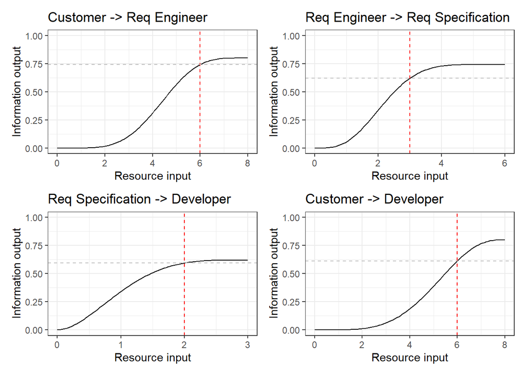

```r
# visualization
plt.customer2reng <- plot.cdf(cdf.beta(alpha = c.elicitation, beta = s.elicitation) * info.customer,
                              range = tmax.elicitation) +
  geom_vline(xintercept = t.elicitation, color = "red", linetype = "dashed") +
  geom_hline(yintercept = info.elicitation, color = "grey", linetype = "dashed") +
  ggtitle("Customer -> Req Engineer")
plt.reng2srs <- plot.cdf(cdf.beta(alpha = c.specification, beta = s.specification) * info.elicitation,
                         range = tmax.specification) +
  geom_vline(xintercept = t.specification, color = "red", linetype = "dashed") +
  geom_hline(yintercept = info.specification, color = "grey", linetype = "dashed") +
  ggtitle("Req Engineer -> Req Specification")
plt.srs2dev <- plot.cdf(cdf.beta(alpha = c.reading, beta = s.reading) * info.specification,
                        range = tmax.reading) +
  geom_vline(xintercept = t.reading, color = "red", linetype = "dashed") +
  geom_hline(yintercept = info.reading, color = "grey", linetype = "dashed") +
  ggtitle("Req Specification -> Developer")

plt.customer2dev <- plot.cdf(cdf.beta(alpha = c.direct, beta = s.direct) * info.customer,
                             range = tmax.direct) +
  geom_vline(xintercept = t.direct, color = "red", linetype = "dashed") +
  geom_hline(yintercept = info.communicating, color = "grey", linetype = "dashed") +
  ggtitle("Customer -> Developer")

(plt.customer2reng | plt.reng2srs) / (plt.srs2dev | plt.customer2dev)
```

## Plotting

Finally, we plot some of the transfer functions for visualization in the manuscript.

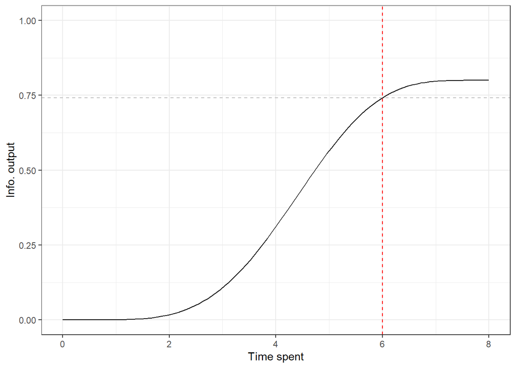

```r
plot.cdf(cdf.beta(alpha = c.elicitation, beta = s.elicitation) * info.customer,
                              range = tmax.elicitation) +
  geom_vline(xintercept = t.elicitation, color = "red", linetype = "dashed") +
  geom_hline(yintercept = info.elicitation, color = "grey", linetype = "dashed") +
  labs(x = "Time spent", y = "Info. output")
```

```r
ggsave("../figures/results/sim-interviewing.png", device = "png", unit = "cm", width = 6, height = 3.5)
```

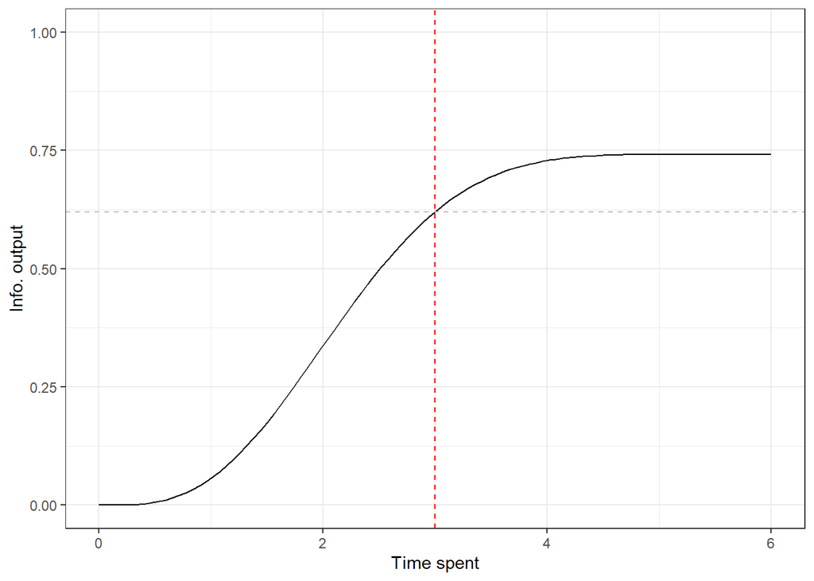

```r
plot.cdf(cdf.beta(alpha = c.specification, beta = s.specification) * info.elicitation,
                         range = tmax.specification) +
  geom_vline(xintercept = t.specification, color = "red", linetype = "dashed") +
  geom_hline(yintercept = info.specification, color = "grey", linetype = "dashed") +
  labs(x = "Time spent", y = "Info. output")
```

```r
ggsave("../figures/results/sim-documenting.png", device = "png", unit = "cm", width = 6, height = 3.5)
```

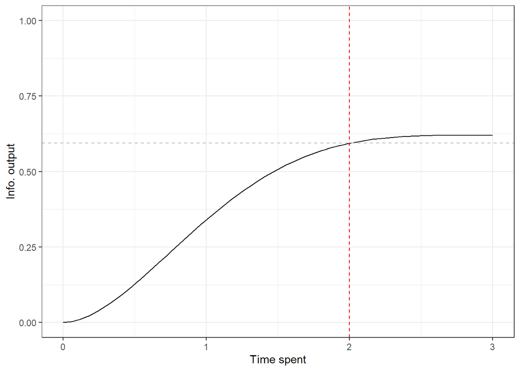

```r
plot.cdf(cdf.beta(alpha = c.reading, beta = s.reading) * info.specification,
                        range = tmax.reading) +
  geom_vline(xintercept = t.reading, color = "red", linetype = "dashed") +
  geom_hline(yintercept = info.reading, color = "grey", linetype = "dashed") +
  labs(x = "Time spent", y = "Info. output")
```

```r
ggsave("../figures/results/sim-reading.png", device = "png", unit = "cm", width = 6, height = 3.5)
```

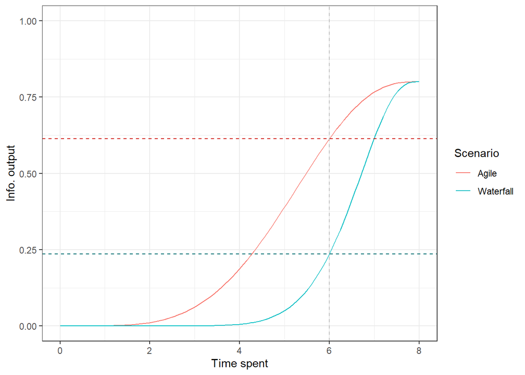

```r
i.communicating.waterfall <- cdf.beta(alpha = 12, beta = 3, x = 6, range = 8)*info.customer
i.communicating.agile <- cdf.beta(alpha = 5, beta = 3, x = 6, range = 8)*info.customer

data.frame(
  x = seq(0, 8, length.out = granularity),
  Waterfall = cdf.beta(alpha = 12, beta = 3) * info.customer,
  Agile = cdf.beta(alpha = 5, beta = 3) * info.customer
) %>%
  pivot_longer(cols = c("Waterfall", "Agile"), names_to = "Scenario", values_to = "i") %>%
  ggplot(aes(x = x, y = i, color = Scenario)) +
    geom_line(aes(group = Scenario)) +
    labs(x = "Time spent", y = "Info. output") +
    geom_vline(xintercept = t.direct, color = "grey", linetype = "dashed") +
    geom_hline(yintercept = i.communicating.waterfall, color = "#006D70", linetype = "dashed") +
    geom_hline(yintercept = i.communicating.agile, color = "#D0180A", linetype = "dashed") +
    ylim(0, 1) +
    theme_bw() +
    theme(legend.position = "right")
```

```r
ggsave("../figures/results/sim-communicating.png", device = "png", unit = "cm", width = 7.5, height = 3.5)
```